# Indel Signature InsDel7

# InsDel7

(corresponds to 83-type signature C_ID7)

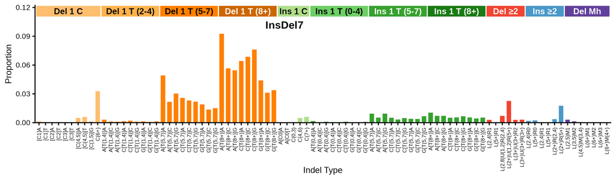

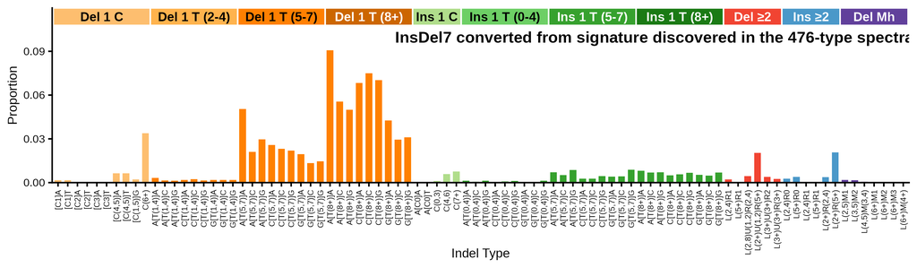

89-type spectrum of the linking tumor WIDE01010075T | cosine similarity to InsDel7: 0.9967

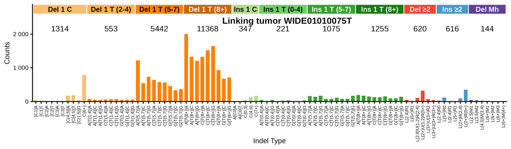

**Click to view decomposition of the linking tumor spectrum**

Partial mutation signature of WIDE01010075T due to InsDel7

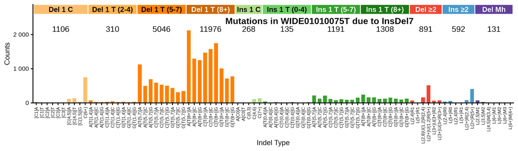

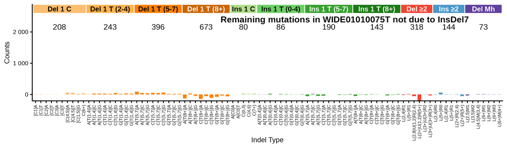

Max neg fraction (maximum allowed negative residual count as fraction of total): 0.15  
N subtract (mutation count assigned to signature): 22955.0  
N residual (mutation count in residual “partial spectrum”): 0.0  
Total negative (sum of negative residual mutation counts): 1277.3  
N negative channels (number of channels with negative residual): 25  
P(≥ total negative) (Monte Carlo estimated probability that negative-binomial-sampled spectra from the signature contributing N subtract mutations would produce a total negative count >= the observed Total negative; higher number means not surprising): 0.995

**Per-channel residual breakdown**

| Channel | Spectrum | Sig_Count | Residual | Sig_Prop |
| --- | --- | --- | --- | --- |
| [Del(C):R1]A | 39 | 30.1 | 8.9 | 0.00131 |
| [Del(C):R1]T | 25 | 15.2 | 9.8 | 0.00066 |
| [Del(C):R2]A | 12 | 6.2 | 5.8 | 0.00027 |
| [Del(C):R2]T | 14 | 6.5 | 7.5 | 0.00028 |
| [Del(C):R3]A | 13 | 7.7 | 5.3 | 0.00033 |
| [Del(C):R3]T | 9 | 7.4 | 1.6 | 0.00032 |
| [Del(C):R(4,5)]A | 174 | 114.8 | 59.2 | 0.00500 |
| [Del(C):R(4,5)]T | 189 | 136.3 | 52.7 | 0.00594 |
| [Del(C):R(1,5)]G | 50 | 31.2 | 18.8 | 0.00136 |
| Del(C):R(6,9) | 789 | 750.9 | 38.1 | 0.03271 |
| A[Del(T):R(1,4)]A | 79 | 72.9 | 6.1 | 0.00317 |
| A[Del(T):R(1,4)]C | 56 | 27.4 | 28.6 | 0.00119 |
| A[Del(T):R(1,4)]G | 53 | 23.5 | 29.5 | 0.00103 |
| C[Del(T):R(1,4)]A | 62 | 32.9 | 29.1 | 0.00143 |
| C[Del(T):R(1,4)]C | 69 | 47.3 | 21.7 | 0.00206 |
| C[Del(T):R(1,4)]G | 69 | 22.5 | 46.5 | 0.00098 |
| G[Del(T):R(1,4)]A | 54 | 32.4 | 21.6 | 0.00141 |
| G[Del(T):R(1,4)]C | 54 | 19.7 | 34.3 | 0.00086 |
| G[Del(T):R(1,4)]G | 57 | 31.4 | 25.6 | 0.00137 |
| A[Del(T):R(5,7)]A | 1217 | 1128.0 | 89 | 0.04914 |
| A[Del(T):R(5,7)]C | 544 | 498.8 | 45.2 | 0.02173 |
| A[Del(T):R(5,7)]G | 736 | 693.2 | 42.8 | 0.03020 |
| C[Del(T):R(5,7)]A | 643 | 592.5 | 50.5 | 0.02581 |
| C[Del(T):R(5,7)]C | 580 | 532.9 | 47.1 | 0.02321 |
| C[Del(T):R(5,7)]G | 565 | 503.4 | 61.6 | 0.02193 |
| G[Del(T):R(5,7)]A | 455 | 436.3 | 18.7 | 0.01901 |
| G[Del(T):R(5,7)]C | 333 | 313.8 | 19.2 | 0.01367 |
| G[Del(T):R(5,7)]G | 369 | 347.3 | 21.7 | 0.01513 |
| A[Del(T):R(8,)]A | 2001 | 2126.1 | -125.1 | 0.09262 |
| A[Del(T):R(8,)]C | 1329 | 1296.4 | 32.6 | 0.05648 |

[output cut: 59 more lines]

**Click to view similar signatures from Koh et al.**

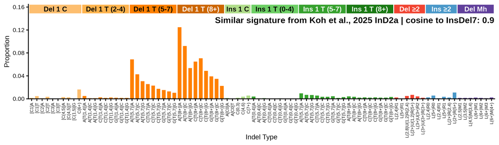

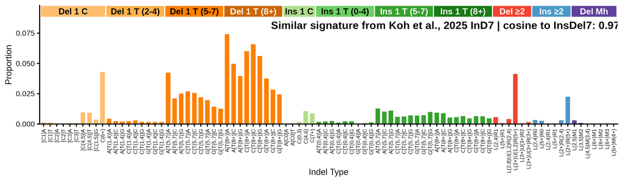

## 476-type representations corresponding to InsDel7

Extracted 476-type signature corresponding to InsDel7

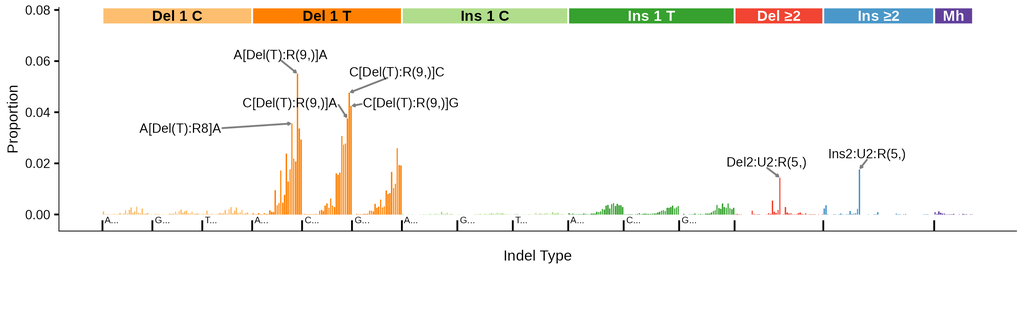

476-type spectrum of the linking tumor WIDE01010075T; cosine similarity to the extracted 476-type signature is 0.9952

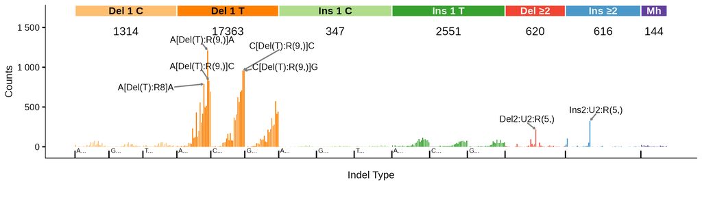

## 83-type signature corresponding to InsDel7 (C_ID7)

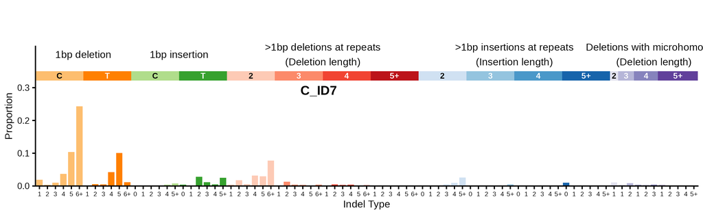

83-type signature converted from signature discovered in the 476-type spectra (using bipartite matching optimization) | cosine similarity to C_ID7: 0.1241

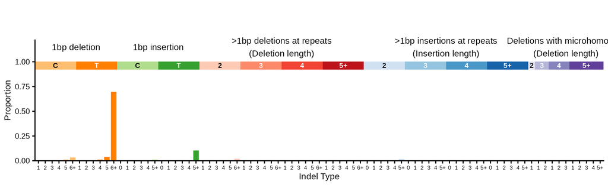

**Click here to see with insertions and deletions of T in long poly-T suppressed**

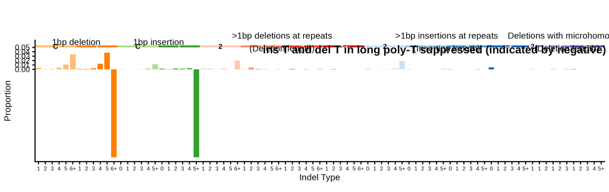

**Click to see flow diagrams: 476-type to 83-type collapse**

These Sankey diagrams show how the 476-type mutation categories are redistributed to 83-type categories using bipartite matching. We only show the diagrams for insertions or deletions of > 1 base because it is for these indels that 476-type categories map to > 1 83-type category.

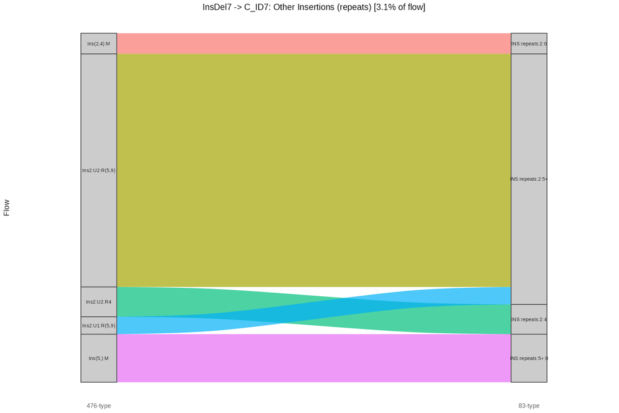

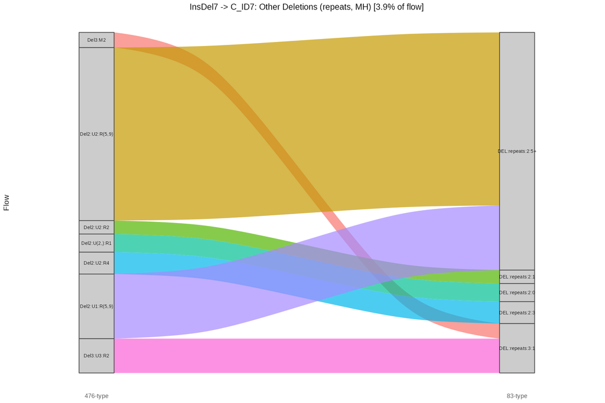

**Caution**

For the linking tumor plot, mutation counts for insertions and deletions of T in long-poly-T contexts were set to 0. They were also set to 0 when calculating cosine similarity with the signature. The signature was not altered when computing the cosine similarity.

83-type spectrum of the linking tumor WIDE01010075T | cosine similarity to C_ID7: 0.8306

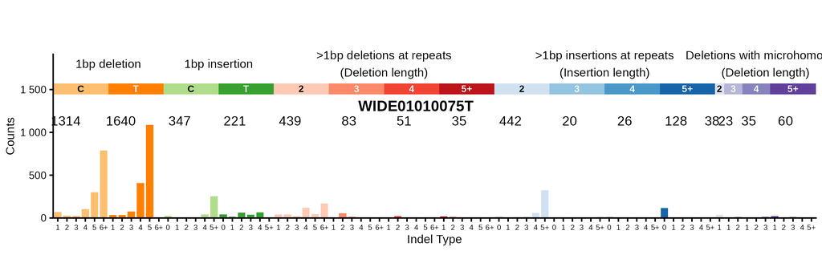

83-type spectrum of best 83-type matching tumor SP13539 | cosine similarity to C_ID7: 0.4808

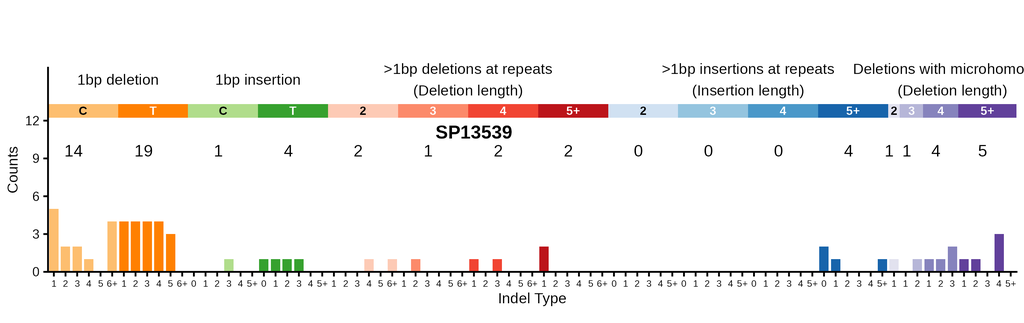

### Similar COSMIC signatures

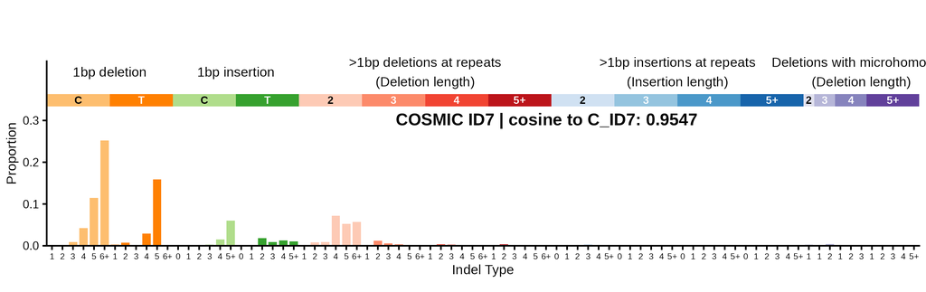